# GG606: Assignment 1 Importing, parsing, and querying data in the wild

Julia K

2024-02-05

## 1. Loading Things:

##### 1.1: Loading Packages

Load in any and all packages required to manipulate, transform, and illustrate the data given.

```r
#Functional:
library(tidyverse)     #Package to process our data, stylized formation
library(dplyr)         #Sub tidyverse package for data manipulation
library(magrittr)      #Package to help coding sequencing
library(janitor)       #Package for 'clean_names()' function
```

```r
library(readr)         #Package to help parse rectangular data
library(stringr)       #Package to deal w/ NAs and manipulate cols/data
library(lubridate)     #Package for date processing and plotting
library(broom.mixed)   #Package to clean diverse model outputs
#Aesthetics:
library(ggplot2)       #Package to generate plotted data
library(patchwork)     #Package for extensive plotted data configuration
library(ggthemes)      #Package for extra themes, scales, and geoms for plotted data
library(RColorBrewer)  #Package to colour plots
library(viridis)       #Package to colour plots
library(here)          #Package to set working directory via `.Rproj`
getwd()                #Function to affirm working directory
```

```
## [1] "C:/Users/jkoza/Documents/GRADUATE SCHOOL/2. COURSEWORK/GG606/GG606_Assignment_1"
```

##### 1.2: Loading Data

```r
countries=read.csv(here("01_raw_data", "countries.csv"))   #load in datasets
earthquakes=read.csv(here("01_raw_data","earthquakes_5.5_1960-2023.csv"))
```

## 2. Manipulating Data:

##### 2.1: Correcting The Main Dataset:

Okay… soooo. A *lot* of stuff happened or tried to happen here. I have removed all lines of code which did not end up working out. But relevant thought processes that stuck around:

- Working with the time kinda messed with my mind. The format given to us is like so: 1960-01-02T12:21:58.720Z (YYYY-MM-DD Time(military): HH:MM:SSS (TimeZone UTC). But the Zulu UTC time was not in the proper format (ex: - 0800) in order to use `%z` or `%Z` in any date formatting sequences.. which is why I removed that last part of the time column. We are not using the time change for any data analysis here, which is why it got cut, but should it have been needed we would have had to continue figuring that out.
- Another failed attempt: `mutate(time=as.POSIXct(time, format="%Y-%m-%dT%H:%M:%S.", tz="UTC"))` this was because I specified `time="1960-01-02T12:21:58"` in line 106 which applied this date to alll the data… (why filtering returned 0 rows)- went and looked at total data rows from `.csv` (matched) but then how many *specifically* were only from 1960 (527) + could not filter dates in environment.
- Here `week_start` doesn’t really matter because it is registering by character not numeric (ex: 1, 2, 3, etc.) and correctly identifies the weekday (changing or removing this piece of code does not have an impact on output).

```r
earthquakes=earthquakes %>%                     #overwrite previous dataset version
  clean_names() %>%                                          #clean all col headers
  mutate(time=str_extract(time, "[[:graph:]T[:graph:]]*(?<=[:punct:])")) %>%
  mutate(time=as.POSIXct(time, format="%Y-%m-%dT%H:%M:%S.",
                         tz="UTC")) %>%                   #convert from chr to date
  mutate(date=as.Date(as.POSIXct(time, format="%Y-%m-%d %H:%M:%S",
                         tz="UTC"))) %>%                      #convert to date type
  mutate(dayofweek=wday(ymd(date), label=TRUE, abbr=FALSE)) %>%            #Mon (1)
  mutate(country=str_extract(place, "(?<=[:graph:], )[:graph:]*")) %>% #get country
  mutate(year=year(date)) %>%                               #col solely for year
  mutate(month=month(date)) %>%                             #col solely for month
  group_by(year) %>%                          #only perform next calc w/ group var
  mutate(avg_mag=mean(mag, na.rm=TRUE)) %>%                    #yearly mag average
  mutate(avg_mag_err=round(mean(mag_error, na.rm=TRUE), 2)) %>%
  select(time, date, year, country, dayofweek, mag, everything(), -nst, -gap,-dmin,
       -rms, -net, -id, -updated, -mag_nst, -status, -location_source, -mag_source) %>%
print()                                      #View object created appears properly
```

```
## # A tibble: 28,835 × 18
## # Groups:   year [64]
##    time                date        year country   dayofweek   mag latitude
##    <dttm>              <date>     <dbl> <chr>     <ord>     <dbl>    <dbl>
##  1 1960-01-02 12:21:58 1960-01-02  1960 <NA>      Saturday   6.31   -55.9
##  2 1960-01-03 11:24:05 1960-01-03  1960 China     Sunday     5.69    43.7
##  3 1960-01-04 06:16:35 1960-01-04  1960 Djibouti  Monday     6.07    11.4
##  4 1960-01-07 08:15:27 1960-01-07  1960 Indonesia Thursday   5.56     6.42
##  5 1960-01-07 13:28:20 1960-01-07  1960 <NA>      Thursday   6.23   -55.6
##  6 1960-01-07 23:17:24 1960-01-07  1960 Indonesia Thursday   5.52     6.40
##  7 1960-01-08 11:29:21 1960-01-08  1960 <NA>      Friday     5.88   -55.6
##  8 1960-01-08 14:46:02 1960-01-08  1960 <NA>      Friday     6.01   -55.6
##  9 1960-01-11 03:10:18 1960-01-11  1960 Myanmar   Monday     5.64    16.0
## 10 1960-01-12 01:52:40 1960-01-12  1960 Taiwan    Tuesday    5.84    23.4
## # ℹ 28,825 more rows
## # ℹ 11 more variables: longitude <dbl>, depth <dbl>, mag_type <chr>,
## #   place <chr>, type <chr>, horizontal_error <dbl>, depth_error <dbl>,
## #   mag_error <dbl>, month <dbl>, avg_mag <dbl>, avg_mag_err <dbl>
```

##### 2.2: Creating a Subdataset:

We are later required to figure out whether North or South America experiences more earthquakes within the 1990s. Thus, we are going create a sub-version of the main data set with only years from the 90s, followed by whether each location is in North or South America.

No need to mutate here because we are overriding the current `date` column with our desired dates, and we are creating a new data frame, so these changes are ‘automatically’ applied to the object.

```r
earthquakes_90s_filtered=earthquakes %>%                          #create new df
  filter(between(date, as.Date("1990-01-01"),              #filter all 90s dates
                               as.Date("1999-12-31"))) %>%
  drop_na(country, mag) %>%               #remove all rows w/o country or mag listed
  mutate(year=year(date)) %>%
  select(time, date, year, country, everything(), -place) %>%            #arrange cols
print()                                    #View object created appears properly
```

```
## # A tibble: 3,812 × 17
## # Groups:   year [10]
##    time                date        year country   dayofweek   mag latitude
##    <dttm>              <date>     <dbl> <chr>     <ord>     <dbl>    <dbl>
##  1 1990-01-02 20:21:32 1990-01-02  1990 Guam      Tuesday     5.8     13.4
##  2 1990-01-04 05:32:21 1990-01-04  1990 Tonga     Thursday    6.5    -15.4
##  3 1990-01-05 10:10:21 1990-01-05  1990 Indonesia Friday      5.8     -8.8
##  4 1990-01-05 13:03:44 1990-01-05  1990 Chile     Friday      5.5    -19.3
##  5 1990-01-05 18:27:00 1990-01-05  1990 Mexico    Friday      6       18.9
##  6 1990-01-07 09:06:43 1990-01-07  1990 Peru      Sunday      5.5    -15.9
##  7 1990-01-08 19:44:34 1990-01-08  1990 Alaska    Monday      6       52.0
##  8 1990-01-09 02:29:26 1990-01-09  1990 India     Tuesday     5.5     28.2
##  9 1990-01-09 04:58:39 1990-01-09  1990 Alaska    Tuesday     5.8     52.0
## 10 1990-01-09 15:35:49 1990-01-09  1990 India     Tuesday     5.7     11.6
## # ℹ 3,802 more rows
## # ℹ 10 more variables: longitude <dbl>, depth <dbl>, mag_type <chr>,
## #   type <chr>, horizontal_error <dbl>, depth_error <dbl>, mag_error <dbl>,
## #   month <dbl>, avg_mag <dbl>, avg_mag_err <dbl>
```

We only want to look at earthquakes from the 90s that we **know** are from either North or South America. When we merge these two data frames we loose some earthquake data that comes from the 90s around the world (we know these countries too, because we removed any place that did *not* have a country) but they are of no use to us because we only want those with the affiliated continents. Here, we affirm that known countries affilated with each continent are being studied, rather than by latitude alone (which we otherwise could have done to have kept more data). Alas.

*Side note: here, `left_join()` is inappropriate because it is trying to create ‘matches’ for all of the existing data in the left table (`earthquakes_90s_filtered`), rather than only keeping rows which match the common column from the right table (`countries`). So `inner_merge()` only keeps rows that match data from both.*

```r
#R is being moody, so we have to break up the code chunks in order for it to
#register previously defined objects, also because I am switching languages to
#get want I want done, which means we can't just 'pipe' it on.
earthquakes_90s_filtered=                                #overwrite previous df
 inner_merged <-
  merge(earthquakes_90s_filtered, countries, by="country") %>%  #merge data sets
  select(time, date, country, continent, everything()) %>%      #reorder cols
print()                                  #view object created appears properly
```

```
##                    time       date   country     continent year dayofweek mag
## 1   1998-06-25 21:03:44 1998-06-25   Antigua North America 1998  Thursday 5.6
## 2   1993-05-24 23:51:20 1993-05-24 Argentina South America 1993    Monday 6.2
## 3   1995-08-03 08:18:53 1995-08-03 Argentina South America 1995  Thursday 5.8
## 4   1998-06-07 16:10:46 1998-06-07 Argentina South America 1998    Sunday 5.9
## 5   1991-06-23 23:14:45 1991-06-23 Argentina South America 1991    Sunday 5.6
## 6   1998-12-14 16:25:24 1998-12-14 Argentina South America 1998    Monday 6.0
## 7   1991-09-15 22:56:20 1991-09-15 Argentina South America 1991    Sunday 5.9
## 8   1997-06-17 22:14:17 1997-06-17 Argentina South America 1997   Tuesday 5.6
## 9   1993-02-24 22:21:37 1993-02-24 Argentina South America 1993 Wednesday 5.7
## 10  1990-09-04 23:15:11 1990-09-04 Argentina South America 1990   Tuesday 5.7
## 11  1998-11-27 10:27:02 1998-11-27 Argentina South America 1998    Friday 5.5
## 12  1994-10-20 01:15:16 1994-10-20 Argentina South America 1994  Thursday 6.0
## 13  1993-05-24 23:51:28 1993-05-24 Argentina South America 1993    Monday 7.0
## 14  1994-05-10 06:36:28 1994-05-10 Argentina South America 1994   Tuesday 6.9
```

[output cut: 1710 more lines]

**Q1: Read the data in and clean it for analysis, using the readr package functions for reading and parsing data. Provide a few comments on the types of earthquakes and the sources of information of the earthquakes. [5 marks]**

- Please see lines and code chunk above for reading, parsing, and manipulating data.
- Magnitudes 6.81 and above appear to be solely related to earthquakes, with the exception of two nuclear explosions of higher magnitudes (6.90 and 6.80).
- The most common magnitude is 5.50 (earthquake). Second highest earthquake magnitude (first country unknown) was in Alaska (9.2). A lot of these high places seem to have like, mountains.
- Most of this information appears to come from only a few main sources: iscgem, us, hrv, and gcmt (Global Centroid Moment Tensor). I could not find what the other organizations were… maybe makes sense considering they were the major contenders from the 60s etc.?

## 3. Producing Figures:

#### 3.1: Question 2

**Q2: Did more earthquakes happen on weekends or weekdays? Include a figure [5 marks]**

- The most common day of the week for earthquakes to occur was a **Wednesday** (n=4220), followed by **Saturday** (n=4210).
- Number of earthquakes on weekends: 8284 (Saturdays=4210 + Sundays=4074), number of earthquakes on weekdays: 20551 (Mondays=4072 + Tuesdays=4026 + etc.). So there have been more earthquakes on M-F weekdays.

*Side note: thoughts on this section… I could not get `mutate()` or `mutate_if()` cases to work here because despite correctly transforming the `dayofweek` column class type from logical to character, it would not be able to mutate on a logical class type. Might this be because of background number affiliated with names (ex: Monday=1)?*  
*`weekend_ls <- list("Saturday", "Sunday")` and `weekday_ls <- list("Monday", "Tuesday", "Wednesday", "Thursday", "Friday")` for `mutate(weekend=filter(dayofweek==weekend_ls))`* `mutate_if(dayofweek, is.logical(weekend=filter(dayofweek %in% c("Saturday", "Sunday"))), as.character)` to no avail.

```r
#Start and run this code if we wanted dates too (ex. yearly weekend vs. weekday)
earthquakes_weekdays=earthquakes %>%                         #create new df
  mutate(dayofweek=as.character(dayofweek)) %>%              #change class type
print()#view object created appears properly
```

```
## # A tibble: 28,835 × 18
## # Groups:   year [64]
##    time                date        year country   dayofweek   mag latitude
##    <dttm>              <date>     <dbl> <chr>     <chr>     <dbl>    <dbl>
##  1 1960-01-02 12:21:58 1960-01-02  1960 <NA>      Saturday   6.31   -55.9
##  2 1960-01-03 11:24:05 1960-01-03  1960 China     Sunday     5.69    43.7
##  3 1960-01-04 06:16:35 1960-01-04  1960 Djibouti  Monday     6.07    11.4
##  4 1960-01-07 08:15:27 1960-01-07  1960 Indonesia Thursday   5.56     6.42
##  5 1960-01-07 13:28:20 1960-01-07  1960 <NA>      Thursday   6.23   -55.6
##  6 1960-01-07 23:17:24 1960-01-07  1960 Indonesia Thursday   5.52     6.40
##  7 1960-01-08 11:29:21 1960-01-08  1960 <NA>      Friday     5.88   -55.6
##  8 1960-01-08 14:46:02 1960-01-08  1960 <NA>      Friday     6.01   -55.6
##  9 1960-01-11 03:10:18 1960-01-11  1960 Myanmar   Monday     5.64    16.0
## 10 1960-01-12 01:52:40 1960-01-12  1960 Taiwan    Tuesday    5.84    23.4
## # ℹ 28,825 more rows
## # ℹ 11 more variables: longitude <dbl>, depth <dbl>, mag_type <chr>,
## #   place <chr>, type <chr>, horizontal_error <dbl>, depth_error <dbl>,
## #   mag_error <dbl>, month <dbl>, avg_mag <dbl>, avg_mag_err <dbl>
```

*Side note: I don’t know why those two lines of code from all of my crazy `group_by` functions didn’t work… which is why I had to manually override any other function types. Normally I would spend more time to ensure that R can compute it correctly, but I unfortunately do not have the grace of time on my side rn*.  
`(group_by(week_type_total) %>% #take those 2 distinct values`  
`mutate(total=sum(week_type_total)) %>% #add them together for all obs (28835))`

```r
#code lines to determine most common appearance of earthquakes (=n observations)
#We for sure know this is true because ALL earthquakes observed have affiliated
#dates with them that we converted to weekdays... thus n=observed earthquakes
#mutate(weeksum=count(dayofweek)) %>% couldn't figure out from code above how to
earthquakes_weekday_sum=earthquakes %>%             #create new df
  count(dayofweek) %>%                              #count how many each weekday appears
  mutate(weekend=case_when(dayofweek %in% c("Saturday", "Sunday")
                           ~TRUE, TRUE ~FALSE)) %>% #create new cols for type
  mutate(weekday=case_when(dayofweek %in% c("Monday", "Tuesday", "Wednesday",
                                        "Thursday", "Friday") ~TRUE, TRUE ~FALSE, )) %>%
  mutate(weekend=case_when(                       #edit TF within cols to what they are
          weekend=="TRUE" ~ "Weekend",)) %>%
  mutate(weekday=case_when(
          weekday=="TRUE" ~ "Weekday")) %>%
  unite(week_type, weekend, weekday, na.rm=TRUE) %>% #merge two cols w/ correct type
#Making data into a percentage:
  group_by(week_type) %>%                            #only perform by objects in col
  mutate(week_type_total=sum(n)) %>%                 #get sum of week/end n all years
  ungroup() %>%
  group_by(dayofweek) %>%                            #only perform by objects in col
  mutate(dayofweek_total=sum(n)) %>%         #get sum of week/end type from all years
  ungroup() %>%
  mutate(total=(8284+20551)) %>%
  mutate(proportion=round((dayofweek_total/(week_type_total))*100,2)) %>%
  #out of either a weekday or weekend, how much was each day?
  mutate(proportion_all=round((week_type_total/(total))*100,2)) %>%
  #out of all days observed, how many were weekdays(MF), how many weekends?
print()                                           #view object created appears properly
```

```
## # A tibble: 448 × 9
##     year dayofweek     n week_type week_type_total dayofweek_total total
##    <dbl> <ord>     <int> <chr>               <int>           <int> <dbl>
##  1  1960 Sunday       40 Weekend              8284            4074 28835
##  2  1960 Monday       37 Weekday             20551            4072 28835
##  3  1960 Tuesday      40 Weekday             20551            4026 28835
##  4  1960 Wednesday    47 Weekday             20551            4220 28835
##  5  1960 Thursday     41 Weekday             20551            4114 28835
##  6  1960 Friday       35 Weekday             20551            4119 28835
##  7  1960 Saturday     38 Weekend              8284            4210 28835
##  8  1961 Sunday       41 Weekend              8284            4074 28835
##  9  1961 Monday       45 Weekday             20551            4072 28835
## 10  1961 Tuesday      32 Weekday             20551            4026 28835
## # ℹ 438 more rows
## # ℹ 2 more variables: proportion <dbl>, proportion_all <dbl>
```

Proportion math for previous data frame `earthquakes_weekday_sum` checks out: week type (weekday/weekend) is 100, and individual weekday or weekend proportions (M/T/W/T/F) checks out too.

So *initially* I have made this stacked bar column to show whether there were more earthquakes on weekdays or weekends, but I found it… slightly less intuitive? I also didn’t like the legend starting with Sunday and ending with Saturday. Code to try and think of method to reorder:  
`weekday_order=c("Monday", "Tuesday", "Wednesday", "Thursday", "Friday")` `weekend_order=c("Saturday", "Sunday")`

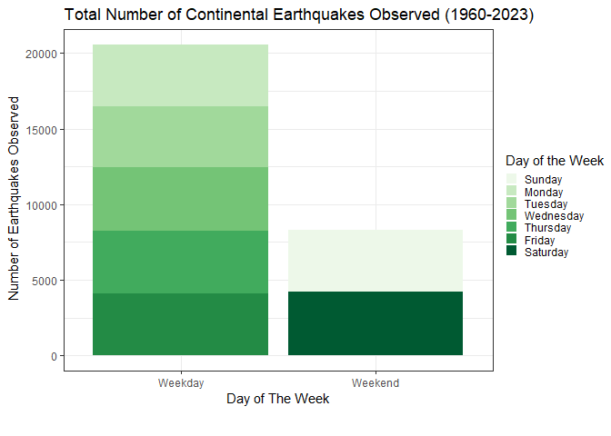

```r
#Generate figure:
q2fig1=earthquakes_weekday_sum %>%                           #create new object
  ggplot() +
  geom_col(aes(x=factor(week_type), y=n, fill=factor(dayofweek))) +
  #geom_text(aes(x="", y="", label=factor(dayofweek_total)), vjust= -0.5, color="black",                   size=3) +
#Edit the scales colour and aesthetics:
  scale_fill_brewer(name="Day of the Week", palette="Greens") +
  theme_bw() +
#Editing the legend:
  theme(legend.position="right") +               #select where the legend rests
  theme(legend.key.size=unit(0.35, 'cm')) +               #decrease legend size
  theme(legend.margin=margin(t=0.25, unit='cm')) +        #reduce legend margin
#Generating label titles:
  labs(title="Total Number of Continental Earthquakes Observed (1960-2023)") +
  theme(plot.title=element_text(hjust=0)) +
  labs(x=expression(atop("Day of The Week")),
     y=expression("Number of Earthquakes Observed"))

print(q2fig1)                             #view object created appears properly
```

Failed nested pie chart attempts to include both levels of data. Which type had more? Within them what was the variability like? I hate these figures and don’t know what they tell us. Q2 Figure 2 was throwing Q2 Figure 1 into a pie chart hoping that it would retain some of its ‘clarity’ into a stacked pie formation. It did not.

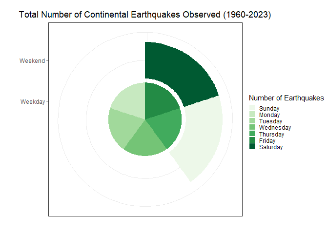

```r
#Generate figure:
q2fig2=earthquakes_weekday_sum %>%                          #create new object
  ggplot() +
  geom_col(aes(x=factor(week_type), y="", fill=factor(dayofweek)), stat="identity") +
  coord_polar(theta="y") +                                 #make barplot into pie
#Edit the scales colour and aesthetics:
  scale_fill_brewer(name="Number of Earthquakes", palette="Greens") +
  theme_bw() +
#Editing legend:
  theme(legend.position="right") +                  #select where the legend rests
  theme(legend.key.size=unit(0.35, 'cm')) +         #decrease legend size
  theme(legend.margin=margin(t=0.25, unit='cm')) +  #reduce legend margin
#Generating label titles:
  labs(title="Total Number of Continental Earthquakes Observed (1960-2023)") +
  theme(plot.title=element_text(hjust=0.5)) +       #auto un-centers title idk why
  labs(x=expression(atop("")),
     y=expression(""))
print(q2fig2)                             #view object created appears properly
```

[figure not shown]

```r
#I couldn't get the pie chart to graph with each column I wanted because there were
#too many data values, only wanted the distinct within each column because we have
#percentage across all rows.
earthquakes_weekday_sumfigure=earthquakes_weekday_sum %>%
  select(-year, -n) %>%
  distinct(dayofweek, .keep_all=TRUE)

#Generate plot:
q2fig3=earthquakes_weekday_sumfigure %>%            #create new object
  ggplot() +
  geom_bar(aes(x="", y="", fill=factor(proportion_all), colour=factor(proportion)),
           stat="identity") +
  coord_polar(theta="y") +
#Edit the scales colour and aesthetics:
  scale_colour_manual(values=c("#ffffff","#FFFEA3","#FFD57A","#FFB16C","#FF926D",
                               "#FF7771", "#FF5261"),
                      labels=c("Monday","Tuesday","Wednesday","Thursday","Friday",
                               "Saturday", "Sunday")) +
  scale_fill_manual(values=c("#a2836e", "#674d3c"),
                      labels=c("Weekday", "Weekend")) +
  theme_bw() +
#Editing legend:
  theme(legend.position="right") +             #select where the legend rests
  theme(legend.key.size=unit(0.35, 'cm')) +         #decrease legend size
  theme(legend.margin=margin(t=0.25, unit='cm')) +  #reduce legend margin
#Generating label titles:
labs(title="Total Number of Continental Earthquakes Observed (1960-2023)") +
  theme(plot.title=element_text(hjust=0.5)) +
  labs(x=expression(atop("")),
     y=expression(""))

print(q2fig3)                     #View object created appears properly
```

[output not shown]

#### 3.2: Question 3

**Has there been any change in the frequency of earthquakes? Include a figure [5 marks]**

- Yes? Based on plotting the total number of earthquakes (all types) throughout time there appears to be an overall slightly positive trend that they are increasing in appearance/frequency.

```r
earthquakes_time=earthquakes %>%                              #create new df
  group_by(year) %>%
  count() %>%
print()                                   #View object created appears properly
```

```
## # A tibble: 64 × 2
## # Groups:   year [64]
##     year     n
##    <dbl> <int>
##  1  1960   278
##  2  1961   248
##  3  1962   215
##  4  1963   309
##  5  1964   394
##  6  1965   458
##  7  1966   306
##  8  1967   341
##  9  1968   405
## 10  1969   414
## # ℹ 54 more rows
```

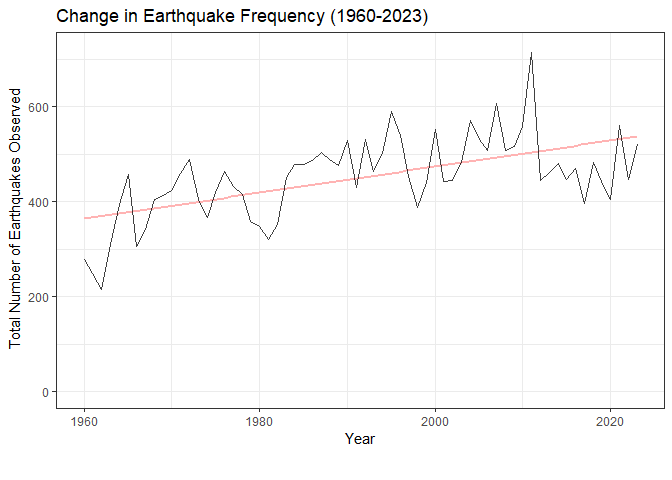

```r
#Generate plot:
q3fig1=earthquakes_time %>%                                 #create new object
  ggplot() +
  geom_smooth(aes(x=year, y=n, colour="trend line"), method= "lm", se=FALSE,
              show.legend=FALSE) +                           #lm line overdrawn
  geom_line(aes(x=year, y=n, colour="data"), alpha=0.75, show.legend=FALSE)+
    xlim(1960,2023) +                                      #adjust plot x-axis
    ylim(0,720) +                                          #adjust plot y-axis
#Edit the scales colour and aesthetics:
  scale_color_manual(values=c("data"="black", "trend line"="#ffb3b3"),
                     labels=c()) +                         #no legend labels
#Editing legend:
  theme_bw() +
  theme(legend.position="right") +              #select where the legend rests
  theme(legend.key.size=unit(0.35, 'cm')) +              #decrease legend size
  theme(legend.margin=margin(t=0.25, unit='cm')) +       #reduce legend margin
  theme(legend.title=element_blank()) +                   #remove legend title
#Generating label titles:
  labs(title="Change in Earthquake Frequency (1960-2023)",       #main caption
       x=expression(atop("Year")),                               #x-axis title
       y=expression("Total Number of Earthquakes Observed"))     #y-axis-title

print(q3fig1)#View object created appears properly
```

Running a quick linear regression does not seem to return any values (incorrectly run?) so I’m not sure if this means such a thing *can’t* be run on this type of data (rise n/run year) or if this is most likely a user error.

```r
earthquakes_time2=earthquakes %>%
  group_by(year, month) %>%
  count() %>%
print()
```

```
## # A tibble: 768 × 3
## # Groups:   year, month [768]
##     year month     n
##    <dbl> <dbl> <int>
##  1  1960     1    21
##  2  1960     2    14
##  3  1960     3    32
##  4  1960     4    11
##  5  1960     5    33
##  6  1960     6    30
##  7  1960     7    27
##  8  1960     8    19
##  9  1960     9    29
## 10  1960    10    22
## # ℹ 758 more rows
```

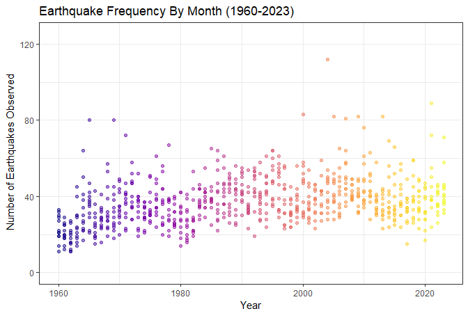

```r
#Generate plot:
q3fig2=earthquakes_time2 %>%                                    #create new df
  ggplot() +
  geom_point(aes(x=year, y=n, colour=factor(year)), alpha=0.5,
             show.legend=FALSE) +
  xlim(1960,2023) +
  ylim(0,125) +             #2011 03: 228 quakes? Removed outlier from view
#Edit the scales colour and aesthetics:
  theme_bw() +
  scale_color_viridis(discrete=TRUE, option="plasma") +
#Generating label titles:
  labs(title="Earthquake Frequency By Month (1960-2023)", #main caption
       x=expression(atop("Year")),                             #x-axis title
       y=expression("Number of Earthquakes Observed"))         #y-axis-title

print(q3fig2)#View object created appears properly
```

#### 3.3: Question 4

**Where were there more earthquakes in the 1990s, South America or North America? Include a figure [5 marks]**

- There were more earthquakes in South America (n=344) than North America (n=230) throughout the 1990s (1990-1999). This data does not account for i.) unidentified countries and ii.) country locations according to latitude, only those formally recognized as being within North or South America.

```r
earthquakes_90s_filtered_sum=earthquakes_90s_filtered %>%
  group_by(continent, year, country) %>%
  count() %>%
print()#View object created appears properly
```

```
## # A tibble: 126 × 4
## # Groups:   continent, year, country [126]
##    continent      year country       n
##    <chr>         <dbl> <chr>     <int>
##  1 North America  1990 Canada        1
##  2 North America  1990 Cuba          1
##  3 North America  1990 Guatemala     2
##  4 North America  1990 Mexico        4
##  5 North America  1990 Nicaragua     4
##  6 North America  1990 Panama        3
##  7 North America  1991 Canada        3
##  8 North America  1991 Guatemala     2
##  9 North America  1991 Mexico       11
## 10 North America  1991 Panama        4
## # ℹ 116 more rows
```

[figure not shown]

```r
#Generate plot:
q4fig1=earthquakes_90s_filtered_sum %>%                      #create new object
  ggplot() +
  geom_bar(aes(fill=factor(year), x=continent, y=n), position="dodge", stat=
             "identity", width=0.75) +
#Edit the scales colour and aesthetics:
  scale_fill_viridis(discrete=TRUE, option="mako") +
#Editing legend:
  theme_bw() +
  theme(legend.position="right") +            #select where the legend rests
  theme(legend.key.size=unit(0.35, 'cm')) +           #decrease legend size
  theme(legend.margin=margin(t=0.25, unit='cm')) +    #reduce legend margin
  theme(legend.title=element_blank()) +                #remove legend title
#Generating label titles:
  labs(title="Change in Earthquake Frequency (1990-1999)", #main caption
       subtitle="Sum of total earthquake types over time in North and South America",
       x=expression(atop("Continent")),                       #x-axis title
       y=expression("Number of Earthquakes Observed"))        #y-axis-title

print(q4fig1)                             #View object created appears properly
```

#### 3.4: Question 5

**Q5: Comment on changes in the data with time: a) earthquakes per year, b) type of earthquakes, and c) magnitude resolution. Include a figure [5 marks]**

```r
earthquakes_frequency_sum=earthquakes %>%  #create new df
  group_by(year, type) %>%
  count() %>%
print()#View object created appears properly
```

```
## # A tibble: 100 × 3
## # Groups:   year, type [100]
##     year type                  n
##    <dbl> <chr>             <int>
##  1  1960 earthquake          278
##  2  1961 earthquake          247
##  3  1961 nuclear explosion     1
##  4  1962 earthquake          215
##  5  1963 earthquake          309
##  6  1964 earthquake          394
##  7  1965 earthquake          458
##  8  1966 earthquake          305
##  9  1966 nuclear explosion     1
## 10  1967 earthquake          341
## # ℹ 90 more rows
```

For some odd, unknown reason I cannot get the following code chunk to knit when there is a header within it. I have tried altering it many times in many ways. Weird.

```r
earthquakes_frequency_sum2=earthquakes %>%               #create new df
  group_by(year) %>%                                    #group variables by year
  count() %>%                                           #number of observations
 left_join(earthquakes_frequency_sum, earthquakes_frequency_sum, by="year") %>%
#Here, n.x=total observed earthquakes per year // n.y=total earthquakes per type
  rename(total_quakes=n.x) %>%                          #rename col header
  rename(total_quakes_per_type=n.y) %>%                 #rename col header
  mutate(type=case_when(                                #rename within `type` col
          type=="earthquake" ~ "Earthquake",
          type=="nuclear explosion" ~ "Nuclear Explosion",
          type=="explosion" ~ "Explosion",
          type=="volcanic eruption" ~ "Volcanic Eruption")) %>%
print()                                   #View object created appears properly
```

```
## # A tibble: 100 × 4
## # Groups:   year [64]
##     year total_quakes type              total_quakes_per_type
##    <dbl>        <int> <chr>                             <int>
##  1  1960          278 Earthquake                          278
##  2  1961          248 Earthquake                          247
##  3  1961          248 Nuclear Explosion                     1
##  4  1962          215 Earthquake                          215
##  5  1963          309 Earthquake                          309
##  6  1964          394 Earthquake                          394
##  7  1965          458 Earthquake                          458
##  8  1966          306 Earthquake                          305
##  9  1966          306 Nuclear Explosion                     1
## 10  1967          341 Earthquake                          341
## # ℹ 90 more rows
```

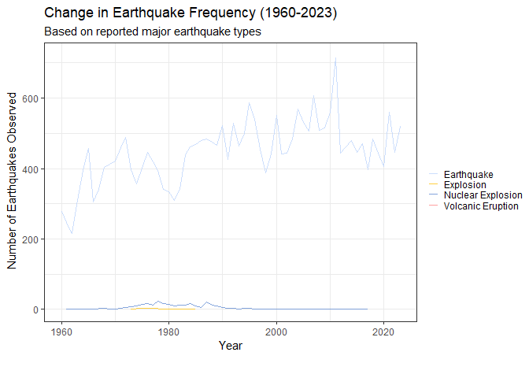

```r
#Generate plot:
q5fig1=earthquakes_frequency_sum2 %>%           #create new object
  ggplot() +
  geom_line(aes(x=year, y=total_quakes_per_type, colour=type, fill=type), alpha=0.75)+
  #  geom_point(aes(x=year, y=total_quakes_per_type, colour=type, fill=type), alpha=.5)+
    xlim(1960,2023) +
    ylim(0,720) +
#Edit the scales colour and aesthetics:
  scale_colour_manual(values=c("#BBD3FB","#ffbf00","#5985D0","#ff8080"),
                      labels=c("Earthquake","Explosion","Nuclear Explosion",
                               "Volcanic Eruption")) +
#  scale_fill_manual(values=c("#BBD3FB","#ffbf00","#5985D0", "#ffffff"),
#                      labels=c("Earthquake","Explosion","Nuclear Explosion",
#                               "Volcanic Eruption")) +
#Editing legend:
  theme_bw() +
  theme(legend.position="right") +            #select where the legend rests
  theme(legend.key.size=unit(0.35, 'cm')) +         #decrease legend size
  theme(legend.margin=margin(t=0.25, unit='cm')) +  #reduce legend margin
  theme(legend.title=element_blank()) +             #remove legend title
#Generating label titles:
  labs(title="Change in Earthquake Frequency (1960-2023)",  #main caption
       subtitle="Based on reported major earthquake types", #sub-caption
       x=expression(atop("Year")),                          #x-axis title
       y=expression("Number of Earthquakes Observed"))      #y-axis-title
print(q5fig1)                 #View object created appears properly
```

I quickly checked that these values were actually computing correctly and they appear to do so. Magnitude average for 1960=6.081 (`avg_mag`); magnitude average for January (month 1) 1960=6.039 and February (month 2) 1960=5.950 and March…. (`avg_mag_ym`) checks out, rounded properly.

*Side note: one thing that happens when code is continuously manipulated down from the larger data frame is it can cause confusion later on from where you’re pulling from. This is also how one ends up with waaaay too many new data frames with various, later absolutely nonsensical, data frame names. In future, loading in a CLEAN data frame consistently with one `Rmarkdown` per figure keeps things more organized.*

Yeah.. but this is tough when you only want specific values, or a smaller subset…

```r
mag=earthquakes %>%
  group_by(year, month) %>%
  mutate(avg_mag_ym=round(mean(mag, na.rm=TRUE), 2)) %>%
  select(date, year, month, avg_mag, avg_mag_err, avg_mag_ym) %>%
print()#View object created appears properly
```

```
## # A tibble: 28,835 × 6
## # Groups:   year, month [768]
##    date        year month avg_mag avg_mag_err avg_mag_ym
##    <date>     <dbl> <dbl>   <dbl>       <dbl>      <dbl>
##  1 1960-01-02  1960     1    6.08        0.31       6.04
##  2 1960-01-03  1960     1    6.08        0.31       6.04
##  3 1960-01-04  1960     1    6.08        0.31       6.04
##  4 1960-01-07  1960     1    6.08        0.31       6.04
##  5 1960-01-07  1960     1    6.08        0.31       6.04
##  6 1960-01-07  1960     1    6.08        0.31       6.04
##  7 1960-01-08  1960     1    6.08        0.31       6.04
##  8 1960-01-08  1960     1    6.08        0.31       6.04
##  9 1960-01-11  1960     1    6.08        0.31       6.04
## 10 1960-01-12  1960     1    6.08        0.31       6.04
## # ℹ 28,825 more rows
```

Here, I did not need to manipulate the scales, so no `ylim(5.5,6.5)` or `xlim(1960,2023)`.

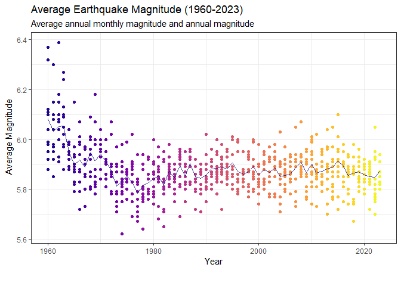

```r
#Generate plot:
q5fig2=mag %>%
  ggplot() +
  geom_point(aes(x=year, y=avg_mag_ym, colour=factor(year)), alpha=0.5,
             show.legend=FALSE) +
  geom_line(aes(x=year, y=avg_mag, colour="#000000"), alpha=0.75, show.legend=FALSE)+
#Edit the scales colour and aesthetics:
  theme_bw() +
  scale_color_viridis(discrete=TRUE, option="plasma") +
#Generating label titles:
  labs(title="Average Earthquake Magnitude (1960-2023)",   #main caption
       subtitle="Average annual monthly magnitude and annual magnitude",
       x=expression(atop("Year")),                         #x-axis title
       y=expression("Average Magnitude"))     #y-axis-title

print(q5fig2)#View object created appears properly
```

#### 3.5: Question 6

**Q6: Comment on how lessons from Wilke’s Fundamentals of Data Visualization were applied to each figure with specific reference to book sections [5 marks]**

- **Q2 Figure 1:** This figure is asking to quantify a particular amount of something, reasonably small (n=2 factors). Wilke states in [Section 6.2](https://clauswilke.com/dataviz/visualizing-amounts.html) that bar charts are good for visualizing amounts of something. However, it should not be too long and ordered from tallest to shortest (should this not interfere with reading the data), as was done within this figure. Also that smaller data set values should have their actual numeric values added as per the recommendation, but I couldn’t get them to work. However, he later states again in [Section 10.3](https://clauswilke.com/dataviz/visualizing-proportions.html) that often times it is difficult to read the data and compare them across stacked bar plots, which is why I then tried to created a nested pie chart instead.
- **Q2 Figure 2:** This figure is a failure and I was unable to use this code as a stepping stone towards creating a better Q2 Figure 3.
- **Q2 Figure 3:** Wilke provides a beautiful nested pie chart in [Section 11.3.](https://clauswilke.com/dataviz/nested-proportions.html) This figure would have probably been the better fit to describe this data, as it matches the prerequisites appropriately: proportion of one variable (weekday or weekend) which can then be subdivided further into another variable (day of the week). I tried to do this, but ultimately failed.
- **Q3 Figure 1:** God. I struggled with this question right to the bitter end, mostly because there could be a couple ways to do this, depending on what you wanted to know or do with the data. I ultimately ended up going with a line graph for a time series plot with a linear regression line at an attempt to classify the trend in data. This is okay-ed by Wilke in [Section 13.1](https://clauswilke.com/dataviz/time-series.html) with reasons expanded upon in Q5 Figure one. However, unlike Wilke later states in [Section 14.2](https://clauswilke.com/dataviz/visualizing-trends.html) if it is non-linear we should approximate what kind of relationship it actually is, which I didn’t do.
- **Q3 Figure 2:** In complete honesty, this figure should have been a heat map for all of the reasons that Wilke states in [Section 6.3:](https://clauswilke.com/dataviz/visualizing-amounts.html) dealing with large data sets that have a lot of points to plot clearly with `geom_point`, and would have done a better job at highlighting a potential overall trend. We don’t necessarily care of the individual values (they don’t plot nicely anyways) so this should have happened.
- **Q4 Figure 1:** Here, we are asked to asses two types of categorical data: continent and a specific time period. As per Wilke in [Section 10.2](https://clauswilke.com/dataviz/visualizing-amounts.html) when there are two categorical variables along the x-axis, grouped bars are able to tackle this. The bar groupings are broken down into two variables: North and South America which is ultimately our main question, then organized by ascending year. This method is more intuitive and easier to look at rather than had we switched these around. Thanks, Wilke.
- **Q5 Figure 1:** Wilke mentions in [Section 13.1](https://clauswilke.com/dataviz/time-series.html) that classic line graphs are good for time series, as was asked of us for question five. In particular, this figure does not include `geom_point` for annual average earthquake values as it can muddle the graph when it is a dense time series (like 63 year’s worth). Also, we are looking for the overall trends in the data throughout time, so yeah, just got rid of them. I also combined those four earthquake types because they are of the same ‘class,’ which was illustrated in the book. I wanted to fill in the line underneath for emphasis, but that was advised against (as per Wilke) because data values should start at zero.
- **Q5 Figure 2:** Under the ‘Visualizing amounts’ in [Section 6.3](https://clauswilke.com/dataviz/visualizing-amounts.html#dot-plots-and-heatmaps) Wilke states that dot pots can be used to display data, especially so when there is no zero start value. Much like here, I wanted to see the overall change in average magnitude (like a time series, which has been recommended for reasons as previously discussed) but did not want to loose the actual values of each point when completely averaged, which is why I went with this type of figure. This shows annual monthly averages too, so we can see a greater change in magnitiude resolution overtime.

#### 4. Closing Thoughts:

Wow. This assignment:

i.) Woke up my R coding brain and troubleshooting skills back from the dead again  
ii.) Making decisions related to figure types is somehow sooo much harder than I ever remember it being. I wasn’t sure how to really connect with this data because I didn’t really know what I wanted to know. Also, that a figure is never complete.

Glad that this small assignment both destroyed and allowed me to become reborn again. Also, I could feel myself start to slip back into my frantic coding self (odd data frame or figure names, creating a multitude of objects with the same name but adding numbers after them, hectic mini code chunks that are ill defined, etc.). So, good to know that that hasn’t gone away and needs to be actively managed more thoroughly in future. Code on (cry).